# Intro to Data Science - HW 3

##### Copyright Jeffrey Stanton, Jeffrey Saltz, and Jasmina Tacheva

```r
# Enter your name here: Patrick Walsh
```

### Attribution statement: (choose only one and delete the rest)

```r
# 1. I did this homework by myself, with help from the book and the professor.
```

### Reminders of things to practice from last week:

Make a data frame data.frame( )  
Row index of max/min which.max( ) which.min( )  
Sort value or order rows sort( ) order( )  
Descriptive statistics mean( ) sum( ) max( )  
Conditional statement if (condition) “true stuff” else “false stuff”

### This Week:

Often, when you get a dataset, it is not in the format you want. You can (and should) use code to refine the dataset to become more useful. As Chapter 6 of Introduction to Data Science mentions, this is called “data munging.” In this homework, you will read in a dataset from the web and work on it (in a data frame) to improve its usefulness.

## Part 1: Use read_csv( ) to read a CSV file from the web into a data frame:

1. Use R code to read directly from a URL on the web. Store the dataset into a new dataframe, called dfComps.  
   The URL is:  
   “https://intro-datascience.s3.us-east-2.amazonaws.com/companies1.csv”  
   **Hint:** use read_csv( ), not read.csv( ). This is from the **tidyverse package**. Check the help to compare them.

```r
library(tidyverse)
dfComps <- read_csv("https://intro-datascience.s3.us-east-2.amazonaws.com/companies1.csv")
```

## Part 2: Create a new data frame that only contains companies with a homepage URL:

5. Use **subsetting** to create a new dataframe that contains only the companies with homepage URLs (store that dataframe in **urlComps**).

```r
urlComps <- dfComps[!(is.na(dfComps$homepage_url)),]
head(urlComps)
```

```
## # A tibble: 6 × 18
##   permalink   name  homep…¹ categ…² market fundi…³ status count…⁴ state…⁵ region
##   <chr>       <chr> <chr>   <chr>   <chr>  <chr>   <chr>  <chr>   <chr>   <chr>
## 1 /organizat… #way… http:/… |Enter… News   1 750 … acqui… USA     NY      New Y…
## 2 /organizat… &TV … http:/… |Games| Games  4 000 … opera… USA     CA      Los A…
## 3 /organizat… 'Roc… http:/… |Publi… Publi… 40 000  opera… EST     <NA>    Talli…
## 4 /organizat… (In)… http:/… |Elect… Elect… 1 500 … opera… GBR     <NA>    London
## 5 /organizat… #NAM… http:/… |Softw… Softw… 1 200 … opera… USA     NY      New Y…
## 6 /organizat… .Clu… http:/… |Softw… Softw… 7 000 … <NA>   USA     FL      Ft. L…
## # … with 8 more variables: city <chr>, funding_rounds <dbl>, founded_at <chr>,
## #   founded_month <chr>, founded_quarter <chr>, founded_year <dbl>,
## #   first_funding_at <chr>, last_funding_at <chr>, and abbreviated variable
## #   names ¹homepage_url, ²category_list, ³funding_total_usd, ⁴country_code,
## #   ⁵state_code
```

4. How many companies are missing a homepage URL?

```r
nrow(dfComps[(is.na(dfComps$homepage_url)),])
```

```
## [1] 3323
```

## Part 3: Analyze the numeric variables in the dataframe.

7. How many **numeric variables** does the dataframe have? You can figure that out by looking at the output of **str(urlComps)**.
8. What is the average number of funding rounds for the companies in **urlComps**?

```r
# G. 2
str(urlComps)
```

```
## tibble [44,435 × 18] (S3: tbl_df/tbl/data.frame)
##  $ permalink        : chr [1:44435] "/organization/waywire" "/organization/tv-communications" "/organization/rock-your-paper" "/organization/in-touch-network" ...
##  $ name             : chr [1:44435] "#waywire" "&TV Communications" "'Rock' Your Paper" "(In)Touch Network" ...
##  $ homepage_url     : chr [1:44435] "http://www.waywire.com" "http://enjoyandtv.com" "http://www.rockyourpaper.org" "http://www.InTouchNetwork.com" ...
##  $ category_list    : chr [1:44435] "|Entertainment|Politics|Social Media|News|" "|Games|" "|Publishing|Education|" "|Electronics|Guides|Coffee|Restaurants|Music|iPhone|Apps|Mobile|iOS|E-Commerce|" ...
##  $ market           : chr [1:44435] "News" "Games" "Publishing" "Electronics" ...
##  $ funding_total_usd: chr [1:44435] "1 750 000" "4 000 000" "40 000" "1 500 000" ...
##  $ status           : chr [1:44435] "acquired" "operating" "operating" "operating" ...
##  $ country_code     : chr [1:44435] "USA" "USA" "EST" "GBR" ...
##  $ state_code       : chr [1:44435] "NY" "CA" NA NA ...
##  $ region           : chr [1:44435] "New York City" "Los Angeles" "Tallinn" "London" ...
##  $ city             : chr [1:44435] "New York" "Los Angeles" "Tallinn" "London" ...
##  $ funding_rounds   : num [1:44435] 1 2 1 1 2 1 1 1 1 1 ...
##  $ founded_at       : chr [1:44435] "1/6/12" NA "26/10/2012" "1/4/11" ...
##  $ founded_month    : chr [1:44435] "2012-06" NA "2012-10" "2011-04" ...
##  $ founded_quarter  : chr [1:44435] "2012-Q2" NA "2012-Q4" "2011-Q2" ...
##  $ founded_year     : num [1:44435] 2012 NA 2012 2011 2012 ...
##  $ first_funding_at : chr [1:44435] "30/06/2012" "4/6/10" "9/8/12" "1/4/11" ...
##  $ last_funding_at  : chr [1:44435] "30/06/2012" "23/09/2010" "9/8/12" "1/4/11" ...
```

```r
# H. 1.7
mean(urlComps$funding_rounds)
```

```
## [1] 1.725194
```

1. What year was the oldest company in the dataframe founded?  
   **Hint:** If you get a value of “NA,” most likely there are missing values in this variable which preclude R from properly calculating the min & max values. You can ignore NAs with basic math calculations. For example, instead of running mean(urlComps$founded_year), something like this will work for determining the average (note that this question needs to use a different function than ‘mean’.

```r
#mean(urlComps$founded_year, na.rm=TRUE)

min(urlComps$founded_year, na.rm=TRUE)
```

```
## [1] 1900
```

## Part 4: Use string operations to clean the data.

11. The **permalink variable** in **urlComps** contains the name of each company but the names are currently preceded by the prefix “/organization/”. We can use str_replace() in tidyverse or gsub() to clean the values of this variable:

```r
urlComps$permalink <- str_replace(urlComps$permalink, "/organization/", "")
head(urlComps)
```

```
## # A tibble: 6 × 18
##   permalink   name  homep…¹ categ…² market fundi…³ status count…⁴ state…⁵ region
##   <chr>       <chr> <chr>   <chr>   <chr>  <chr>   <chr>  <chr>   <chr>   <chr>
## 1 waywire     #way… http:/… |Enter… News   1 750 … acqui… USA     NY      New Y…
## 2 tv-communi… &TV … http:/… |Games| Games  4 000 … opera… USA     CA      Los A…
## 3 rock-your-… 'Roc… http:/… |Publi… Publi… 40 000  opera… EST     <NA>    Talli…
## 4 in-touch-n… (In)… http:/… |Elect… Elect… 1 500 … opera… GBR     <NA>    London
## 5 n-plusn     #NAM… http:/… |Softw… Softw… 1 200 … opera… USA     NY      New Y…
## 6 club-domai… .Clu… http:/… |Softw… Softw… 7 000 … <NA>   USA     FL      Ft. L…
## # … with 8 more variables: city <chr>, funding_rounds <dbl>, founded_at <chr>,
## #   founded_month <chr>, founded_quarter <chr>, founded_year <dbl>,
## #   first_funding_at <chr>, last_funding_at <chr>, and abbreviated variable
## #   names ¹homepage_url, ²category_list, ³funding_total_usd, ⁴country_code,
## #   ⁵state_code
```

12. Can you identify another variable which should be numeric but is currently coded as character? Use the as.numeric() function to add a new variable to **urlComps** which contains the values from the char variable as numbers. Do you notice anything about the number of NA values in this new column compared to the original “char” one?

```r
# The large number of NA values in this new column is due to the spaces in the original char column which prevents R from converting the char characters to numbers.

urlComps$funding_total_usd_NUM <- as.numeric(urlComps$funding_total_usd)
urlComps$funding_total_usd_NUM[1:500]
```

[output not shown]

13. To ensure the char values are converted correctly, we first need to remove the spaces between the digits in the variable. Check if this works, and explain what it is doing:

```r
# The code adds a new column to the urlComps dataframe by using the stri_replace_all_charclass() function. This function copies the
# funding_total_usd column with spaces removed. The format for this function is:
# stri_replace_all_charclass(string, pattern, replacement)

library(stringi)
urlComps$funding_new <- stri_replace_all_charclass(urlComps$funding_total_usd,"\\p{WHITE_SPACE}", "")
urlComps$funding_new[1:500]
```

```
##   [1] "1750000"   "4000000"   "40000"     "1500000"   "1200000"   "7000000"
##   [7] "4912393"   "2000000"   "-"         "41250"     "10600000"  "40000"
##  [13] "-"         "1750000"   "2050000"   "40000"     "500000"    "-"
##  [19] "2535000"   "4962651"   "4059079"   "10000000"  "3000000"   "3000000"
##  [25] "1250000"   "35000000"  "50000"     "1600000"   "100000"    "-"
##  [31] "3000000"   "77500"     "-"         "20000000"  "1800000"   "-"
##  [37] "-"         "270000"    "794000"    "650267"    "-"         "-"
##  [43] "378812"    "130636"    "619494"    "-"         "66450000"  "-"
##  [49] "700000"    "5500000"   "500000"    "6204822"   "3400000"   "200000"
##  [55] "50000"     "14000000"  "84440319"  "2500000"   "9478511"   "-"
##  [61] "200000000" "40000"     "-"         "-"         "-"         "40000"
##  [67] "43811"     "50000"     "-"         "1450000"   "2100000"   "4163132"
##  [73] "170000"    "30000000"  "500000"    "-"         "2572969"   "-"
##  [79] "156000"    "30000"     "10000000"  "117000000" "750000"    "1500000"
##  [85] "1660000"   "41250"     "204189"    "150000"    "29750000"  "1236454"
```

[output cut: 69 more lines]

[output not shown]

N. You are now ready to convert **urlComps$funding_new** to numeric using as.numeric().

Calculate the average funding amount for **urlComps**. If you get “NA,” try using the **na.rm=TRUE** argument from problem I.

```r
urlComps$funding_new_NUM <- as.numeric(urlComps$funding_new)
mean(urlComps$funding_new_NUM, na.rm=TRUE)
```

```
## [1] 18321551
```

Sample three unique observations from urlComps$funding_rounds, store the results in the vector ‘observations’

```r
observations <- sample(urlComps$funding_rounds, 3, replace=FALSE)
observations
```

```
## [1] 3 1 2
```

Take the mean of those observations

```r
mean(observations)
```

```
## [1] 2
```

Do the two steps (sampling and taking the mean) in one line of code

```r
mean(observations <- sample(urlComps$funding_rounds, 3, replace=FALSE))
```

```
## [1] 1
```

Explain why the two means are (or might be) different

Use the replicate( ) function to repeat your sampling of three observations of urlComps$funding_rounds observations five times. The first argument to replicate( ) is the number of repeats you want. The second argument is the little chunk of code you want repeated.

```r
# In this case, the two means are different since they are random samplings of the vector. If we wanted to ensure that the samples
# are the same each time, we could use the set.seed() function to some numeric value, such as set.seed(5).

replicate(5, sample(urlComps$funding_rounds, 3, replace=FALSE))
```

```
##      [,1] [,2] [,3] [,4] [,5]
## [1,]    1    1    1    1    1
## [2,]    1    3    1    1    1
## [3,]    2    1    1    1    2
```

Rerun your replication, this time doing 20 replications and storing the output of replicate() in a variable called **values**.

```r
values <- replicate(20, sample(urlComps$funding_rounds, 3, replace=FALSE))
```

Generate a **histogram** of the means stored in **values**.

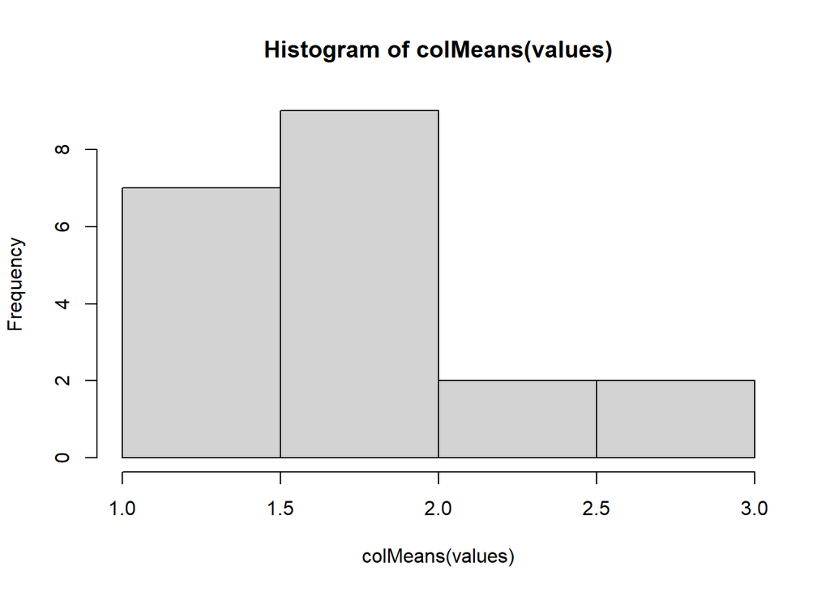

```r
hist(colMeans(values))
```

Rerun your replication, this time doing 1000 replications and storing the output of replicate() in a variable called **values**, and then generate a histogram of **values**.

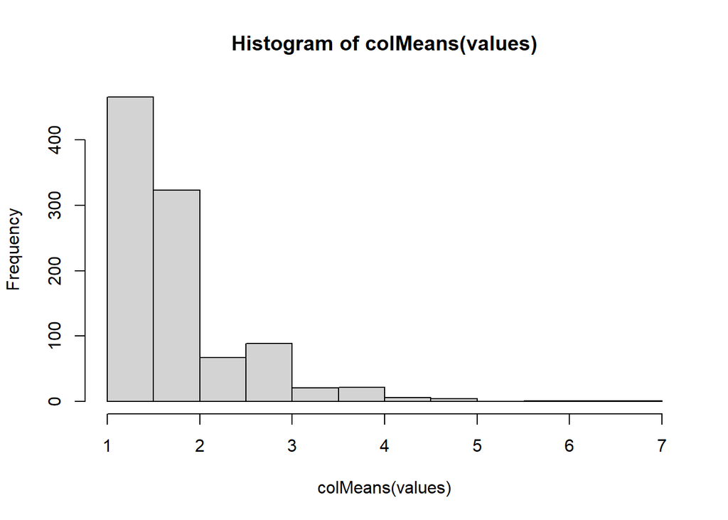

```r
values <- replicate(1000, sample(urlComps$funding_rounds, 3, replace=FALSE))
hist(colMeans(values))
```

Repeat the replicated sampling, but this time, raise your sample size from 3 to 22. How does that affect your histogram? Explain in a comment.

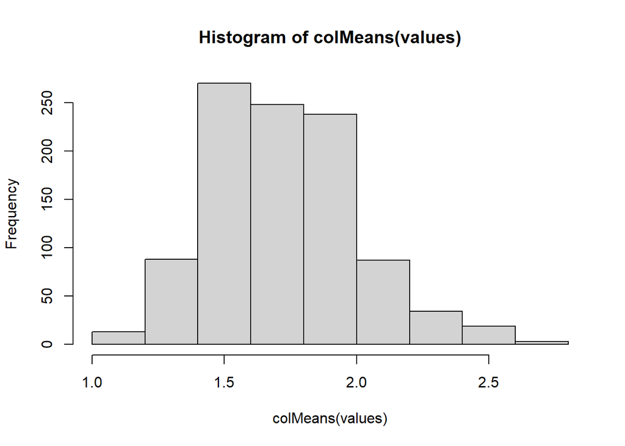

```r
values <- replicate(1000, sample(urlComps$funding_rounds, 22, replace=FALSE))
hist(colMeans(values))
```

```r
# Increasing the sample size helps to normalize the distribution of the histogram. Larger sampling helps to bring the values
# closer to the mean which improves the histogram distribution, as explained here: # https://medium.com/geekculture/how-increasing-sample-size-will-improve-gaussian-distribution-ae2bf5c5abaf
```

Explain in a comment below, the last three histograms, why do they look different?

```r
# The first two histograms are right skewed, where most of the data falls on the left side of the diagram. This is because
# the sample size is low, giving the column means low values on average. With the second histogram, there are more samples,
# making the skewness more even and the pattern more clear. It isn't until we get to the third histogram that we see the
# histogram start to become normalized since the sample sizes are increased, bringing the means closer to the center of the histogram.
```